# Introdução à disciplina e revisão de aprendizado de máquina

Interpretabilidade de Aprendizado de Máquina

**[Bruno Iochins Grisci](https://brunogrisci.github.io/)**

[Universidade Federal do Rio Grande do Sul](https://www.ufrgs.br/site/)  
[Instituto de Informática](https://www.inf.ufrgs.br/site/)  
[Departamento de Informática Teórica](https://www.inf.ufrgs.br/site/estrutura/departamentos/)  
[Programa de Pós-Graduação em Computação](https://www.inf.ufrgs.br/ppgc/)

## Programa

1. Apresentação da disciplina
2. Aprendizado de máquina

# Apresentação da disciplina

## Dados Gerais

**Disciplina(s):**

- [CMP633 – Tópicos Especiais em Computação DCXXXIII: Interpretabilidade de Aprendizado de Máquina](https://www.inf.ufrgs.br/ppgc/disciplinas/lista-de-disciplinas/cmp633/)
- INF05030 – TÓPICOS ESPECIAIS EM COMPUTAÇÃO XLII

**Professor:** Bruno Iochins Grisci

**Carga horária:** 60 h (50 h em sala de aula, 10 h em atividades autônomas)

**Créditos:** 4

## Sobre o Professor

**Bruno Iochins Grisci**

- **E-mail:** bigrisci@inf.ufrgs.br
- **Site:** https://brunogrisci.github.io/
- **Presencial:** Sala 235, prédio 43425 (segundo andar)

**Interesses:**

- Inteligência Artificial.
- Aprendizado de Máquina Interpretável.
- Bioinformática.
- Computação Evolutiva.
- Análise de Redes.

[figure not shown]

[@explain.ufrgs](https://www.instagram.com/explain.ufrgs/)

## Sobre o Professor

**Disciplinas no antigo currículo:**

- INF05008 – Fundamentos de Algoritmos
- INF05512 – Teoria dos Grafos e Análise Combinatória
- INF05501 – Teoria da Computação N

**Disciplinas no novo currículo:**

- INF05027 – Projeto e Análise de Algoritmos I
- INF05501 – Teoria da Computação II

**Disciplinas na Licenciatura:**

- CREAD049 – Inteligência Artificial na Educação

**Disciplinas na Pós-Graduação:**

- [CMP626 – Theory of Computation](https://www.inf.ufrgs.br/ppgc/disciplinas/lista-de-disciplinas/CMP626)
- [CMP633 – Tópicos Especiais em Computação DCXXXIII: Interpretabilidade de Aprendizado de Máquina](https://www.inf.ufrgs.br/ppgc/disciplinas/lista-de-disciplinas/cmp633/)

## Bibliografia

- **Interpretable Machine Learning: A Guide for Making Black Box Models Explainable (3rd ed.)**. Christoph Molnar. https://christophm.github.io/interpretable-ml-book/
- **Understanding Deep Learning**. Simon J. D. Prince. https://udlbook.github.io/udlbook/

Para quem nunca estudou *deep learning*: **Neural Networks and Deep Learning**. Michael Nielsen. http://neuralnetworksanddeeplearning.com/

Além dos artigos compartilhados pelo professor.

[figure not shown]

[figure not shown]

## Moodle

**Moodle:**  
https://moodle.ufrgs.br/course/view.php?id=165286

- Toda a comunicação oficial.
- Disponibilização de slides, atividades, material complementar.
- Avaliações.

## Avaliação

**Atividades avaliadas:**

- Questionário (2 pontos)
- Laboratórios (4 pontos)
- Projeto (4 pontos)

$$NF = 0{,}2 \times Q + 0{,}4 \times L + 0{,}4 \times P$$

O conceito é definido a partir de $NF$, da forma tradicional:

A ($\geq 9$),

B ($\geq 7{,}5$),

C ($\geq 6$),

D ($< 6$),

FF (menos de 75% de frequência).

## Questionário

- 2,0 pontos.
- Liberado na parte final do semestre.
- Atividade autônoma e remota.
- Permitida a consulta.
- Entrega no final do semestre.
- Maior que uma prova tradicional.

## Laboratórios

- 4 ao longo do semestre.
- Atividades avaliadas (1,0 ponto cada).
- Lab 4 faz parte do andamento do projeto (protótipo).
- Entrega individual, mas com discussão e consulta liberadas.
- **Presencial!** (exceto casos justificados).
- Implementação de algoritmos e realização de análises na prática.
- Linguagem de programação preferencial: Python.

## Projeto

Atividade em vários estágios durante todo o semestre.

- Valor: 4 + 1 pontos.
- Em grupos constantes.
- Tema livre dentro das opções da disciplina.
- Avaliações na segunda metade do semestre, mas o recomendado é começar assim que possível.
- Etapas:
  - Proposta: 0,5 pts
  - Protótipo (Lab 4): 1 pt
  - Relatório (em forma de artigo): 2 pts
  - Apresentação: 1,5 pt

É necessário assistir aos colegas dos demais grupos para pontuar, salvo faltas justificadas.

Na prática, a nota da apresentação irá influenciar na nota do relatório e vice-versa.

## Atividades de recuperação

**Exame de recuperação:**

Está previsto um exame de recuperação (EXAME), a ser realizado após o fechamento da NF e versando sobre todo o conteúdo da disciplina, apenas para alunos com 75% ou mais de presença.

Após a realização do exame, a nota do aluno será recalculada (NE) como segue:

$$NE = 0{,}2 \times NF + 0{,}8 \times EXAME$$

O novo conceito será atribuído com base em $NE$, conforme os critérios acima.

## Uso de IA generativa

O foco desta disciplina não é necessariamente o desenvolvimento de código ou a programação, embora essas atividades façam parte dela.

Boa parte das ferramentas, dos métodos e dos algoritmos que estudaremos já possui boas implementações disponíveis em bibliotecas padrão (principalmente em Python).

Assim sendo, é permitido o uso de IA generativa no desenvolvimento do projeto avaliado (nos laboratórios não deve ser necessário).

Contudo, o uso deve ser consciente e crítico, baseado justamente nos conhecimentos adquiridos ao longo do semestre.

## Deep learning

Iremos estudar *deep learning*?

- Sim, mas de forma explícita a partir da metade do semestre.

Iremos estudar IA generativa, transformers, etc.?

- Sim, mas no final do semestre. Tenham calma.

## Cronograma preliminar

[interactive chart not shown]

[Abrir o cronograma no Google Sheets](https://docs.google.com/spreadsheets/d/1upoqmG779GHvYYEXaEXPrNXimhBv5FreWfcZf4gcMvM/edit?usp=sharing)

## Contexto no curso

**Base matemática**

- Probabilidade e estatística
- Cálculo diferencial
- Álgebra linear

**Inteligência artificial**

- Aprendizado de máquina
- Aprendizado profundo
- Ciência de dados

Introduziremos os conceitos aos poucos, à medida que forem necessários.

Boa parte da matemática necessária é relativamente simples.

## Contexto no curso II

**Para saber mais**

- [CMP263 – Aprendizagem de Máquina](https://www.inf.ufrgs.br/ppgc/disciplinas/lista-de-disciplinas/CMP263)
- [CMP627 – Aprendizado Profundo](https://www.inf.ufrgs.br/ppgc/disciplinas/lista-de-disciplinas/CMP627)
- [CMP273 – Visual Analytics for Data Science](https://www.inf.ufrgs.br/ppgc/disciplinas/lista-de-disciplinas/cmp273/)

## O que esse curso NÃO é

- Não é um **substituto** para as disciplinas de aprendizado de máquina, aprendizado profundo e similares (mas foi planejado para poder ser acompanhado sem ter esse estudo formal).
- Não é um curso de **avaliação** de desempenho de IA (embora as métricas de avaliação sejam essenciais).
- Não é um curso de **ética** nem de **segurança** de IA (mas está bastante relacionado a esses tópicos, que serão abordados).

## O que esse curso é

## Por que estudar interpretabilidade?

- Área com muitos problemas de pesquisa em aberto e espaço para contribuições significativas.
- Espaço para projetos de pesquisa que não se limitam a “bater *benchmark*.”
- Reconhecimento como área de estudo essencial para o avanço e adoção da IA do ponto de vista técnico e ético.
- Alto impacto social.
- Porque é muito interessante e divertido (como veremos).

# Aprendizado de máquina

## Roteiro desta revisão

1. Inteligência artificial: ideias e abordagens
2. O que significa uma máquina aprender?
3. Dados, modelos e tipos de aprendizado
4. Aprendizado indutivo e supervisionado
5. Generalização e avaliação de modelos

O objetivo é estabelecer uma linguagem comum para o restante da disciplina.

## O que é inteligência artificial?

> O esforço para automatizar tarefas intelectuais normalmente realizadas por seres humanos.

> — François Chollet (2018)

Em termos operacionais, queremos construir sistemas capazes de:

- perceber ou representar aspectos do ambiente;
- raciocinar, planejar, decidir ou aprender;
- agir para atingir algum objetivo.

**Mas como reproduzir uma capacidade humana cuja regra nem sempre sabemos descrever?**

[figure not shown]

Na Antiguidade, seres artificiais capazes de pensar serviam como recursos narrativos: Talos, um autômato gigante feito de bronze, protegia Creta de piratas e invasores (vaso do século V a.C.).

[*Talos* — Wikipedia](https://en.wikipedia.org/wiki/Talos)

## Duas tradições de IA

### IA simbólica

- Conhecimento representado explicitamente.
- Regras, lógica, busca e planejamento.
- O programa enumera ou investiga soluções.
- Execução geralmente rastreável e transparente.
- Difícil de escalar quando as regras não podem ser formalizadas.

### IA baseada em aprendizado

- Conhecimento adquirido a partir de exemplos.
- O sistema extrai regularidades dos dados.
- O desempenho pode melhorar com experiência.
- O modelo treinado responde rapidamente.
- O raciocínio aprendido pode ser difícil de rastrear.

## IA simbólica: representações explícitas

**Sistema especialista**

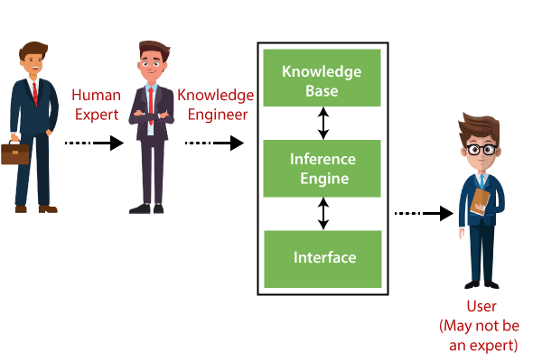

**Máquina de estados**

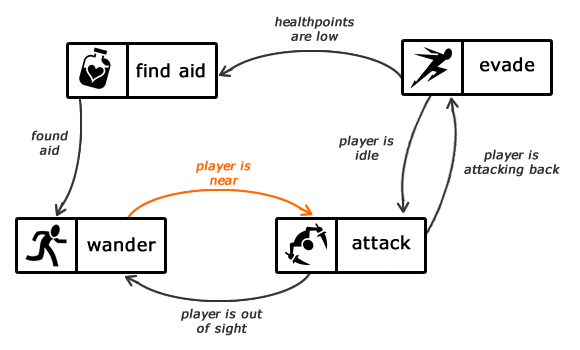

**Busca de caminhos**

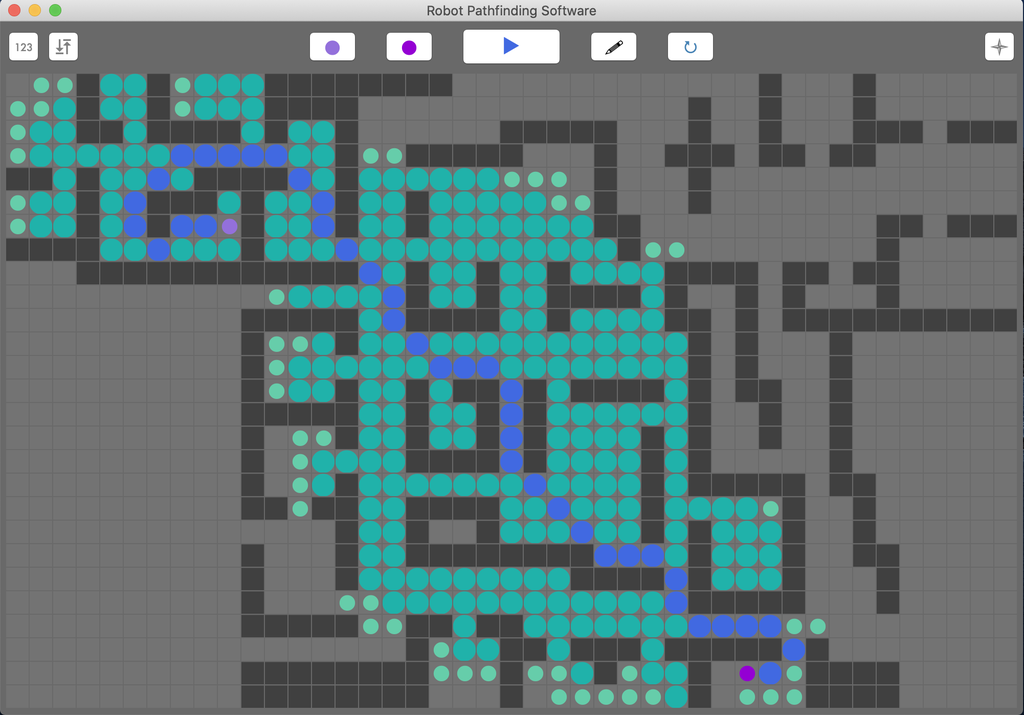

Outros exemplos: representação de conhecimento, prova de teoremas, planejamento e algoritmos de busca.

## Programação ou aprendizado?

[figure not shown]

Na programação tradicional, fornecemos **dados e regras** para produzir respostas.

Em aprendizado de máquina, fornecemos **dados e respostas conhecidas** para induzir um modelo.

## IA, aprendizado de máquina e aprendizado profundo

- **Inteligência artificial:** campo mais amplo; inclui abordagens baseadas ou não em aprendizado.
- **Aprendizado de máquina:** sistemas que ajustam seu comportamento a partir de dados ou experiência.
- **Aprendizado profundo:** modelos de ML compostos por sucessivas camadas de representações aprendidas.

## Da IA simbólica para o aprendizado

[figure not shown]

**Deep Blue (1996):** busca, conhecimento do domínio e avaliação programada.

[figure not shown]

**AlphaGo (2016):** aprendizado a partir de jogos, redes neurais e busca.

Sistemas reais podem combinar componentes simbólicos, busca, otimização e aprendizado.

## Um exemplo de impacto: AlphaFold

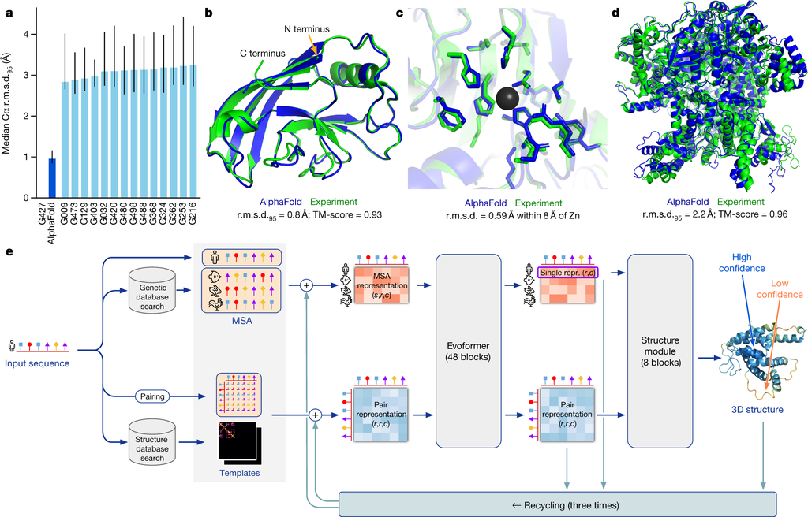

Predizer a estrutura tridimensional de uma proteína a partir de sua sequência foi um desafio científico de décadas.

O AlphaFold ilustra como regularidades aprendidas a partir de grandes bases de dados podem complementar experimentos e conhecimento científico.

Fonte: [Jumper et al. (2021). *Highly accurate protein structure prediction with AlphaFold*](https://www.nature.com/articles/s41586-021-03819-2)

## O que torna o aprendizado possível?

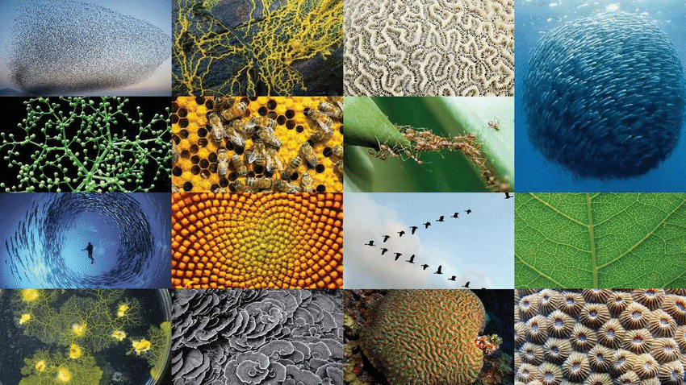

*Emergence in Urban Environments: Agent-based Simulation of Environment Reconfiguration* (2016). [DOI: 10.13140/RG.2.2.14814.13121](https://doi.org/10.13140/RG.2.2.14814.13121).

O aprendizado de máquina pressupõe que existem **estruturas e regularidades** que podem ser descobertas a partir dos exemplos e reaplicadas a novos casos.

Sem regularidade, os dados passados não informariam o futuro.

## O que é aprendizado de máquina?

**Arthur Samuel (1959):** campo de estudo que dá aos computadores a capacidade de aprender sem serem explicitamente programados.

**Herbert Simon (1953):** aprendizado é um processo pelo qual um sistema melhora seu desempenho com a experiência.

**Tom Mitchell (1997):** um programa aprende a partir da experiência $E$, em relação a uma tarefa $T$ e a uma medida de desempenho $P$, se seu desempenho em $T$, medido por $P$, melhora com $E$.

**Aurélien Géron (2017):** a ciência e a arte de programar computadores para que aprendam a partir de dados.

[figure not shown]

[Arthur Samuel jogando damas — IBM](https://www.ibm.com/history/early-games)

## Tarefa, experiência e desempenho

**Problema:** reconhecer caracteres manuscritos.

- **Tarefa $T$:** reconhecer e classificar os caracteres.
- **Experiência $E$:** imagens rotuladas de caracteres manuscritos.
- **Desempenho $P$:** proporção de caracteres corretamente classificados — ou outra medida coerente com o uso real.

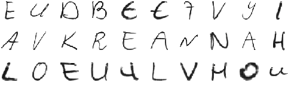

Uma especificação de ML está incompleta se não disser **o que se aprende**, **com que experiência** e **segundo qual critério**.

## Aprender é generalizar

**Generalização:** usar uma regularidade descoberta em uma amostra para tomar decisões ou fazer predições sobre dados ainda não vistos.

- Repetir um cálculo iterativo não é, por si só, aprendizado.
- Memorizar perfeitamente os exemplos também não garante aprendizado útil.
- A pergunta decisiva é: **o modelo funciona fora dos dados usados para ajustá-lo?**

## O que é um modelo?

Um **modelo** é uma representação ajustada a partir dos dados para descrever uma regularidade ou aproximar uma relação de interesse.

$$\widehat{f}: \mathcal{X} \rightarrow \mathcal{Y},
\qquad \widehat{y}=\widehat{f}(\mathbf{x})$$

- $\mathbf{x}$: atributos que descrevem uma instância;
- $\widehat{y}$: saída ou predição;
- $\widehat{f}$: relação aprendida;
- **modelo = representação + parâmetros ajustados**.

O algoritmo de aprendizado é o procedimento que produz o modelo.

## Três componentes do aprendizado

> **Aprendizado = Representação + Avaliação + Otimização**
- **Representação:** quais formas o modelo pode assumir?
- **Avaliação:** como medimos a qualidade de uma solução?
- **Otimização:** como procuramos uma boa solução no espaço permitido?

Exemplo: regressão linear = função com pesos lineares + erro quadrático + um procedimento para ajustar os pesos.

## Quatro elementos de representação

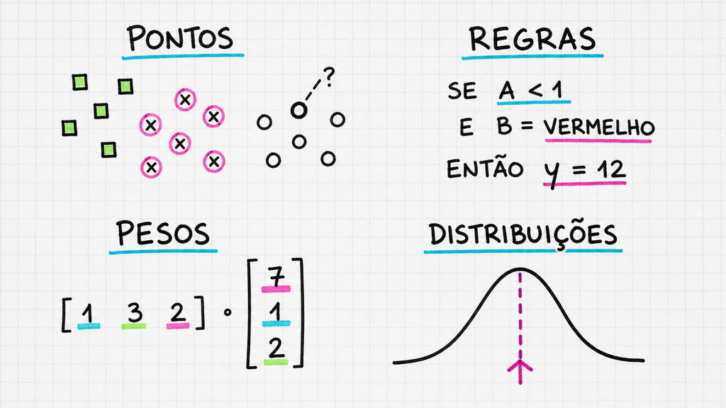

[Molnar (2025) — *Points, Rules, Weights, Distributions*](https://mindfulmodeler.substack.com/p/points-rules-weights-distributions)

- **Pontos:** protótipos no espaço de atributos. Exemplos: $k$-NN e $k$-means.
- **Regras:** condições *se–então*. Exemplos: árvores, listas de regras e florestas.
- **Pesos:** vetores, matrizes ou tensores. Exemplos: modelos lineares, SVM e redes neurais.
- **Distribuições:** relações probabilísticas. Exemplos: Naive Bayes e processos gaussianos.

São **lentes predominantes**, não categorias mutuamente exclusivas.

## O dataset Palmer Penguins

[**Palmer Penguins** — Horst, Hill e Gorman (2020)](https://allisonhorst.github.io/palmerpenguins/). Dados coletados por Kristen Gorman com o Palmer Station LTER; ilustração por Allison Horst (@allison_horst).

## Um problema, quatro representações

Gráfico interativo dos pinguins: ative JavaScript para mover o novo caso.

Os modelos usam os mesmos 342 exemplos completos e os mesmos dois atributos padronizados; os eixos permanecem em milímetros.

## Pontos: $k$-vizinhos mais próximos

Demonstração interativa do k-NN indisponível sem JavaScript.

O conjunto de treinamento funciona como memória; distâncias e votos são calculados no momento da consulta.

## Regras: árvore de decisão

Demonstração interativa da árvore indisponível sem JavaScript.

A árvore particiona o espaço com testes sucessivos e produz regiões retangulares.

## Pesos: regressão logística

Demonstração interativa da regressão logística indisponível sem JavaScript.

Cada classe recebe um escore: intercepto + contribuições ponderadas dos atributos; o *softmax* os transforma em probabilidades.

## Distribuições: Gaussian Naive Bayes

Demonstração interativa do Naive Bayes indisponível sem JavaScript.

As elipses mostram um e dois desvios-padrão; o alinhamento aos eixos reflete a independência condicional assumida.

## Mesmos dados, fronteiras diferentes

Comparação interativa das quatro fronteiras indisponível sem JavaScript.

Clique em qualquer painel: o mesmo caso é atualizado nos quatro. Formas diferentes podem concordar localmente e se comportar de modo distinto em outras regiões.

## Da representação à predição

| Elemento predominante | O modelo conserva | Para predizer | Para aprender |
| --- | --- | --- | --- |
| **Pontos** ($k$-NN) | exemplos de referência | distâncias e voto local | quase nenhum ajuste; *lazy learning* |
| **Regras** (árvore) | limiares e folhas | segue testes *se–então* | busca gulosa por partições |
| **Pesos** (logística) | coeficientes e interceptos | combina atributos e aplica *softmax* | minimiza uma perda numérica |
| **Distribuições** (Naive Bayes) | probabilidades *a priori*, médias e variâncias | combina probabilidades condicionais | estima parâmetros por classe |

Escolher um algoritmo também é escolher **como representar e procurar regularidades**.

## Paradigmas de aprendizagem

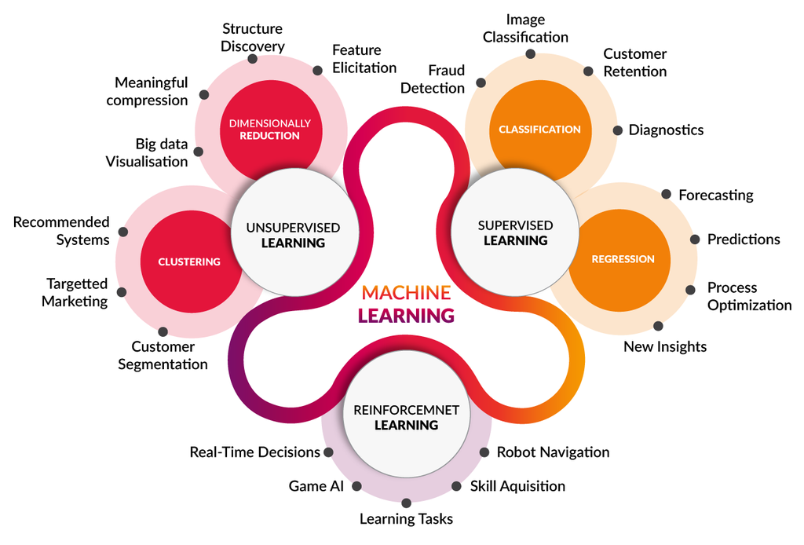

Fonte: [Chua, R. (2019), *A simple way to explain how machines learn in the AI world*](https://becominghuman.ai/a-simple-way-to-explain-how-machines-learn-7d9155ac8bed).

Perguntas diferentes exigem dados, feedback, representações e critérios de avaliação diferentes.

## Tipos de feedback e de tarefa

| Feedback | Paradigma | Tarefa típica | Objetivo |
| --- | --- | --- | --- |
| Completo: entradas e saídas esperadas | supervisionado | classificação, regressão | prever um alvo |
| Parcial: recompensa ou crítica | por reforço | controle, decisões sequenciais | maximizar retorno |
| Nulo: sem saída esperada | não supervisionado | agrupamento, associação | descrever estrutura |

O aprendizado **semissupervisionado** combina poucos exemplos rotulados com muitos exemplos não rotulados.

## Aprendizado por reforço

Gridworld interativo de aprendizado por reforço indisponível sem JavaScript.

- Um **agente** observa um estado e escolhe uma ação.
- O **ambiente** retorna um novo estado e uma recompensa.
- As decisões afetam experiências futuras.
- O objetivo é aprender uma política que maximize a recompensa acumulada.

Exemplos: jogos, robótica, controle adaptativo e decisões sequenciais.

Saiba mais: [Sutton e Barto (2015)](https://web.stanford.edu/class/psych209/Readings/SuttonBartoIPRLBook2ndEd.pdf)

## Aprendizado não supervisionado

O algoritmo recebe exemplos sem uma saída esperada e procura estruturas nos dados.

Comparação interativa entre aprendizado não supervisionado e supervisionado indisponível sem JavaScript.

Mesmos pinguins e atributos nos dois painéis; muda a informação fornecida ao algoritmo. Clique ou arraste o ponto ⊕.

- **Agrupamento:** identificar grupos de instâncias semelhantes.
- **Associação:** encontrar relações recorrentes entre variáveis ou eventos.
- A interpretação do significado dos padrões ainda depende do contexto.

## Aprendizado supervisionado

O algoritmo recebe exemplos para os quais as saídas esperadas são conhecidas.

- Cada instância é representada pelo par $(\mathbf{x},y)$.
- O **indutor** constrói um modelo a partir dos exemplos de treinamento.
- O modelo deve predizer a saída de novos exemplos.
- Alvo categórico $\rightarrow$ **classificação**.
- Alvo numérico $\rightarrow$ **regressão**.

O foco não é reproduzir respostas conhecidas, mas aprender uma relação que **generalize**.

## Indução de hipóteses

Considere os exemplos:

| $x$ | 1 | 2 | 3 | 4 | 5 | 6 | 7 | 8 |
| --- | --- | --- | --- | --- | --- | --- | --- | --- |
| $y$ | 1 | 4 | 9 | 16 | 25 | 36 | 49 | 64 |

**Indução:** dos casos particulares para uma hipótese geral.

$$h(x)=x^2$$

**Dedução:** dada a hipótese, calcular uma consequência: $h(12)=144$.

Os dados não determinam sozinhos uma única hipótese; a representação e as preferências do algoritmo introduzem um **viés indutivo**.

## Treinamento vs. Predição

**Treinar é otimizar ou encontrar os parâmetros do modelo. Predizer é usar o modelo aprendido.**

| Treinamento | Predição |
| --- | --- |
| recebe atributos e respostas | recebe apenas os atributos |
| modifica os parâmetros | mantém os parâmetros fixos |
| produz um modelo | produz uma resposta |
| mais caro e menos frequente | mais barato e frequente |

## Formulação do aprendizado supervisionado

Dados de treinamento:

$$\mathcal{D}=\{(\mathbf{x}_k,y_k)\}_{k=1}^{n},
\qquad \mathbf{x}_k\in\mathcal{X},\quad y_k\in\mathcal{Y}.$$

Queremos aprender $\widehat{f}$ tal que:

$$\widehat{f}(\mathbf{x}) \approx f(\mathbf{x})$$

também para $\mathbf{x}$ que não pertence aos dados de treinamento.

O conjunto $\mathcal{D}$ é uma **amostra**; o objetivo real está na **população ou distribuição** que gerou os casos.

## Predição supervisionada

### Classificação

Prediz um valor categórico.

> Dadas as medidas do bico, a qual espécie pertence o pinguim?

Visualização interativa da classificação indisponível sem JavaScript.

$$\widehat{f}(\mathbf{x})\in\{c_1,c_2,\ldots,c_m\}$$

$m=2$: binária; $m>2$: multiclasse. Aqui, $m=3$.

### Regressão

Prediz um valor numérico.

> Dado o comprimento da nadadeira, qual é a massa corporal estimada do pinguim?

Visualização interativa da regressão indisponível sem JavaScript.

$$\widehat{f}(\mathbf{x})\in\mathbb{R}$$

A escala do erro faz parte da definição do problema.

## Famílias de algoritmos supervisionados

- **Baseados em pontos e distâncias:** $k$-vizinhos mais próximos.
- **Simbólicos e baseados em regras:** árvores de decisão.
- **Estatísticos e baseados em pesos/distribuições:** regressão linear, regressão logística, Naive Bayes.
- **Baseados em margens:** máquinas de vetores de suporte.
- **Conexionistas:** redes neurais artificiais.
- **Conjuntos de modelos:** florestas aleatórias, *bagging*, *boosting* e *stacking*.

Todos aprendem algum tipo de regularidade, mas diferem em representação, otimização, custo, suposições e comportamento fora da amostra.

## Aprendizado semissupervisionado

Situação comum: dados são abundantes, mas rótulos são caros.

- O objetivo preditivo é semelhante ao do aprendizado supervisionado.
- Apenas uma parte dos exemplos de treinamento possui rótulo.
- A estrutura dos dados não rotulados ajuda a restringir o que pode ser aprendido.

Exemplos:

- imagens abundantes, poucas anotadas por especialistas;
- grande coleção de textos, pequena amostra categorizada;
- exames clínicos, poucos com diagnóstico confirmado.

## Classificação como partição do espaço

Um classificador divide o espaço de atributos em **regiões de decisão**.

Comparação interativa das partições indisponível sem JavaScript.

$$\mathcal{X}=R_1\cup R_2\cup\cdots\cup R_m,
\qquad
\widehat{f}(\mathbf{x})=c_j \text{ se } \mathbf{x}\in R_j.$$

A fronteira entre essas regiões é a **fronteira de decisão**.

- Fronteiras simples podem errar exemplos conhecidos, mas ser mais estáveis.
- Fronteiras muito flexíveis podem memorizar irregularidades da amostra.
- O que importa é o desempenho sobre novos exemplos.

## Erro ou custo: classificação

Para cada pinguim $i$, $y_{ik}\in\{0,1\}$ indica se ele pertence à classe $k$. Treinar é escolher parâmetros que reduzam o **custo médio**:

$$\ell_i^{\mathrm{CE}}(\boldsymbol{\theta})
=-\sum_{k=1}^{K}y_{ik}\log\widehat p_{ik}(\boldsymbol{\theta}),
\qquad
J_{\mathrm{CE}}(\boldsymbol{\theta})
=\frac{1}{n}\sum_{i=1}^{n}\ell_i^{\mathrm{CE}}(\boldsymbol{\theta}),
\qquad
\widehat{\boldsymbol{\theta}}
=\arg\min_{\boldsymbol{\theta}}J_{\mathrm{CE}}(\boldsymbol{\theta}).$$

**Regressão logística multiclasse:** o custo por entropia cruzada é baixo quando o modelo atribui alta probabilidade à classe correta e cresce rapidamente quando essa probabilidade se aproxima de zero. Visualização interativa indisponível sem JavaScript.

**Erro 0–1** observa apenas se $\widehat y_i\neq y_i$; a entropia cruzada também avalia a **confiança** da predição.

Saiba mais: [Reinventing Entropy | Compression is Intelligence Part 1](https://www.youtube.com/watch?v=l6DKRf-fAAM) e [But what is cross-entropy? | Compression is Intelligence Part 2](https://www.youtube.com/watch?v=GlYgs6v2YfU)

## Erro ou custo: regressão

Na regressão, o treinamento pode minimizar a média dos erros quadráticos:

$$\widehat{\boldsymbol{\theta}}
=\arg\min_{\boldsymbol{\theta}}J_{\mathrm{MSE}}(\boldsymbol{\theta}),
\qquad
J_{\mathrm{MSE}}
=\frac{1}{n}\sum_{i=1}^{n}\ell_i^{\mathrm{SE}},
\qquad
\ell_i^{\mathrm{SE}}=\left(y_i-\widehat y_i\right)^2.$$

**Regressão linear simples:** a distância entre cada valor observado e sua predição é elevada ao quadrado e então agregada no erro quadrático médio. Visualização interativa indisponível sem JavaScript.

O **resíduo** preserva a direção do erro; o quadrado evita cancelamentos e faz erros grandes pesarem mais.

## Treino, validação e teste

- **Treino:** ajusta os parâmetros do modelo.
- **Validação:** orienta escolhas de representação, hiperparâmetros e limiares.
- **Teste:** fornece uma estimativa final em dados não usados nas escolhas anteriores.

$$\mathcal{D}=\mathcal{D}_{\text{treino}}\;\dot\cup\;
\mathcal{D}_{\text{validação}}\;\dot\cup\;
\mathcal{D}_{\text{teste}}$$

**Vazamento de dados:** qualquer uso de informações dos conjuntos de validação ou de teste durante o treinamento ou o pré-processamento produz uma avaliação otimista.

## Ajuste, subajuste e sobreajuste

| Situação | No treinamento | Em novos dados | Interpretação |
| --- | --- | --- | --- |
| **Subajuste** (*underfitting*) | erro alto | erro alto | padrão não capturado |
| **Bom compromisso** | erro controlado | erro semelhante | regularidades capturadas |
| **Sobreajuste** (*overfitting*) | erro muito baixo | erro alto | amostra memorizada |

Comparação interativa indisponível sem JavaScript.

**Erro de treinamento não é uma estimativa suficiente de generalização.**

## Avaliar é especificar o que importa

- A função usada para treinar é um **substituto quantitativo** para o objetivo do mundo real.
- Métricas conectam uma pergunta do domínio a uma quantidade mensurável.
- Modelos diferentes podem ser melhores segundo critérios diferentes.
- Uma boa métrica deve refletir os custos dos erros e o uso previsto do sistema.

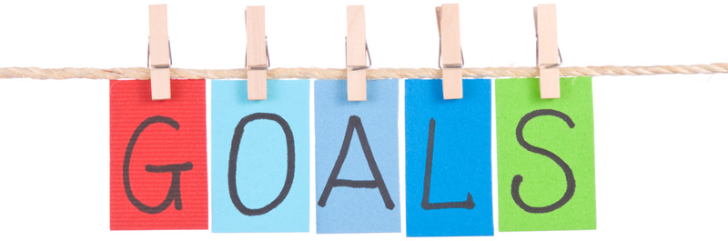

**O que medimos direciona o que otimizamos.**

## Matriz de confusão binária

**Modelo:** $k$-NN multiclasse ($k=3$), interpretado como um classificador binário: Adelie contra o restante · **positivo:** Adelie · **negativo:** Não Adelie (Chinstrap ou Gentoo).

|  | Predito como Adelie (+) | Predito como Não Adelie (−) |
| --- | --- | --- |
| **Real Adelie (+)** | VP | FN |
| **Real Não Adelie (−)** | FP | VN |

- **VP:** caso positivo corretamente predito como positivo.
- **VN:** caso negativo corretamente predito como negativo.
- **FP:** caso negativo incorretamente predito como positivo.
- **FN:** caso positivo incorretamente predito como negativo.

Visualização interativa indisponível sem JavaScript.

## Matriz de confusão multiclasse

**Mesmo modelo e mesma divisão:** $k$-NN ($k=3$) · 70% para treino e 30% para teste · linhas = realidade, colunas = predição.

Cada linha representa uma espécie real e cada coluna uma espécie predita. A diagonal contém os acertos; as demais células mostram quais espécies foram confundidas.

Visualização interativa indisponível sem JavaScript.

## Métricas de classificação — Acurácia

Matriz de teste: VP = 45, FN = 0, FP = 1 e VN = 56. Visualização interativa indisponível sem JavaScript.

**Acurácia:** proporção total de predições corretas.

$$\operatorname{Acc}=\frac{VP+VN}{VP+VN+FP+FN}$$

Com os dados de teste:

$$\operatorname{Acc}
=\frac{45+56}{45+56+1+0}
=\frac{101}{102}
\approx \mathbf{99{,}0\%}.$$

Os **acertos** formam o numerador; todos os casos aparecem no denominador.

## Métricas de classificação — Sensibilidade

Matriz de teste: VP = 45, FN = 0, FP = 1 e VN = 56. Visualização interativa indisponível sem JavaScript.

**Sensibilidade** (*recall* da classe positiva): entre os positivos reais, quantos foram detectados?

$$\operatorname{Sens}=\frac{VP}{VP+FN}$$

Com os dados de teste:

$$\operatorname{Sens}
=\frac{45}{45+0}
=\frac{45}{45}
=\mathbf{100{,}0\%}.$$

A sensibilidade percorre a linha dos casos reais da classe **Adelie**.

## Métricas de classificação — Especificidade

Matriz de teste: VP = 45, FN = 0, FP = 1 e VN = 56. Visualização interativa indisponível sem JavaScript.

**Especificidade:** entre os negativos reais, quantos foram reconhecidos?

$$\operatorname{Esp}=\frac{VN}{VN+FP}$$

Com os dados de teste:

$$\operatorname{Esp}
=\frac{56}{56+1}
=\frac{56}{57}
\approx \mathbf{98{,}2\%}.$$

A especificidade percorre a linha dos casos reais da classe **Não Adelie**.

## Métricas de classificação — Precisão

Matriz de teste: VP = 45, FN = 0, FP = 1 e VN = 56. Visualização interativa indisponível sem JavaScript.

**Precisão** (*positive predictive value*): entre os casos preditos como positivos, quantos são realmente positivos?

$$\operatorname{Prec}=\frac{VP}{VP+FP}$$

Com os dados de teste:

$$\operatorname{Prec}
=\frac{45}{45+1}
=\frac{45}{46}
\approx \mathbf{97{,}8\%}.$$

A precisão percorre a coluna dos casos **preditos como Adelie**.

## Métricas de classificação — $F_1$

Matriz de teste: VP = 45, FN = 0, FP = 1 e VN = 56. Visualização interativa indisponível sem JavaScript.

**$F_1$:** média harmônica entre precisão e sensibilidade.

$$F_1=2\frac{\operatorname{Prec}\cdot\operatorname{Sens}}
{\operatorname{Prec}+\operatorname{Sens}}$$

Em termos das células da matriz:

$$F_1=\frac{2VP}{2VP+FP+FN}$$

Com os dados de teste:

$$F_1=\frac{2\cdot45}{2\cdot45+1+0}
=\frac{90}{91}
\approx \mathbf{98{,}9\%}.$$

$F_1$ resume duas propriedades, mas não torna os custos de FP e FN automaticamente equivalentes.

## A armadilha da acurácia

Suponha 1.000 casos, dos quais apenas 10 são positivos.

Um classificador que sempre prediz “negativo” obtém:

$$\operatorname{Acc}=\frac{990}{1000}=99\%
\qquad\text{e}\qquad
\operatorname{Sens}=\frac{0}{10}=0\%.$$

- Acurácia alta não implica utilidade.
- O desbalanceamento de classes muda a interpretação das métricas.
- Sempre compare com *baselines* simples.
- Examine a matriz de confusão e métricas por classe.

Saiba mais: [Dorn et al. (2021). *Comparison of machine learning techniques to handle imbalanced COVID-19 CBC datasets*](https://doi.org/10.7717/peerj-cs.670)

## Qual métrica escolher?

| Se o custo dominante é… | Priorize/observe… | Exemplo |
| --- | --- | --- |
| perder um caso positivo | sensibilidade, FN | triagem de doença grave |
| gerar um alarme falso | especificidade, FP | investigação cara ou invasiva |
| confiar em alertas positivos | precisão | revisão humana com capacidade limitada |
| equilibrar precisão e sensibilidade | $F_1$ e ambas as parcelas | recuperação de informação |
| desempenho global com classes equilibradas | acurácia e matriz de confusão | erros com custos semelhantes |

Em algumas aplicações, a melhor métrica é específica do domínio e deve incorporar custos, benefícios, prevalência e limiares de decisão.

## Outras métricas

|  | População total \(=P+N\) | Condição predita Predito positivo | Condição predita Predito negativo | Medidas derivadas **Informedness** (BM) \(=TPR+TNR-1\) | Medidas derivadas **Limiar de prevalência** (PT) \(=\frac{\sqrt{TPR\,FPR}-FPR}{TPR-FPR}\) |
| --- | --- | --- | --- | --- | --- |
| Condição real | Positivo real (P) | **Verdadeiro positivo** (VP) acerto positivo | **Falso negativo** (FN) omissão · erro do tipo II | **Taxa de verdadeiros positivos** (TPR) recall · sensibilidade \(=\frac{VP}{P}=1-FNR\) | **Taxa de falsos negativos** (FNR) taxa de omissão \(=\frac{FN}{P}=1-TPR\) |
|  | Negativo real (N) | **Falso positivo** (FP) alarme falso · erro do tipo I | **Verdadeiro negativo** (VN) rejeição correta | **Taxa de falsos positivos** (FPR) fall-out \(=\frac{FP}{N}=1-TNR\) | **Taxa de verdadeiros negativos** (TNR) especificidade \(=\frac{VN}{N}=1-FPR\) |
|  | **Prevalência** \(=\frac{P}{P+N}\) | **Valor preditivo positivo** (PPV) precisão \(=\frac{VP}{VP+FP}=1-FDR\) | **Taxa de omissão falsa** (FOR) \(=\frac{FN}{VN+FN}=1-NPV\) | **Razão de verossimilhança positiva** (LR+) \(=\frac{TPR}{FPR}\) | **Razão de verossimilhança negativa** (LR−) \(=\frac{FNR}{TNR}\) |
|  | **Acurácia** (ACC) \(=\frac{VP+VN}{P+N}\) | **Taxa de falsas descobertas** (FDR) \(=\frac{FP}{VP+FP}=1-PPV\) | **Valor preditivo negativo** (NPV) \(=\frac{VN}{VN+FN}=1-FOR\) | **Markedness** (MK) \(=PPV+NPV-1\) | **Diagnostic odds ratio** (DOR) \(=\frac{\mathrm{LR+}}{\mathrm{LR-}}=\frac{VP\,VN}{FP\,FN}\) |
|  | **Acurácia balanceada** (BA) \(=\frac{TPR+TNR}{2}\) | **Escore \(F_1\)** \(=\frac{2\,PPV\,TPR}{PPV+TPR}=\frac{2VP}{2VP+FP+FN}\) | **Índice de Fowlkes–Mallows** (FM) \(=\sqrt{PPV\,TPR}\) | **Correlação de Matthews** (MCC) \(=\frac{VP\,VN-FP\,FN}{\sqrt{(VP+FP)(VP+FN)(VN+FP)(VN+FN)}}\) | **Threat score / Jaccard** (TS/CSI) \(=\frac{VP}{VP+FN+FP}\) |

Tabela adaptada de [*Evaluation of binary classifiers* — Wikipedia](https://en.wikipedia.org/wiki/Evaluation_of_binary_classifiers). P e N representam os totais de positivos e negativos reais.

## Antes de treinar um modelo

1. Qual é a pergunta e quem usará a resposta?
2. Qual é a instância, quais são os atributos e qual é o alvo?
3. Os dados representam os casos em que o modelo será usado?
4. Qual paradigma de aprendizado corresponde ao feedback disponível?
5. Como separar treino, validação e teste sem vazamento?
6. Qual métrica traduz melhor os custos dos erros?
7. Contra qual *baseline* o modelo será comparado?

**Aprendizado de máquina é um processo de modelagem e avaliação, não apenas a execução de um algoritmo.**

## Projeto de um sistema de aprendizado

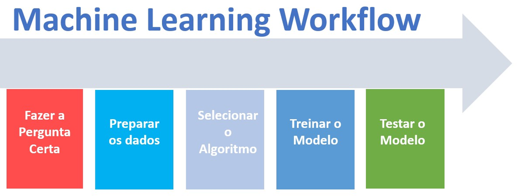

**Cuidado:** começar pelo algoritmo, sem definir o problema e a avaliação, costuma inverter a ordem das decisões.

**Escopo:** esse fluxo preditivo não descreve diretamente o aprendizado por reforço.

1. Formular a tarefa, o contexto de uso, a função-alvo e a unidade de predição.
2. Definir a experiência de treinamento; obter, compreender e preparar os dados.
3. Escolher representações e algoritmos.
4. Treinar e ajustar o modelo.
5. Definir a avaliação; testar, interpretar e revisar as decisões.

# Pergunta

## Pergunta

Se já temos tantas maneiras de avaliar o desempenho de métodos de aprendizado de máquina e sabemos o quanto um modelo acerta ou erra, para que precisamos de interpretabilidade?

## E se?

- E se o modelo não tiver boa qualidade preditiva e quisermos investigar o porquê?
- E se dois modelos tiverem o mesmo desempenho? Eles terão aprendido as mesmas representações?
- E se eu quiser saber qual característica de um pinguim é mais relevante para descobrir a sua espécie?

## E se?

**E se o modelo classificar o pinguim corretamente pelos motivos errados?**

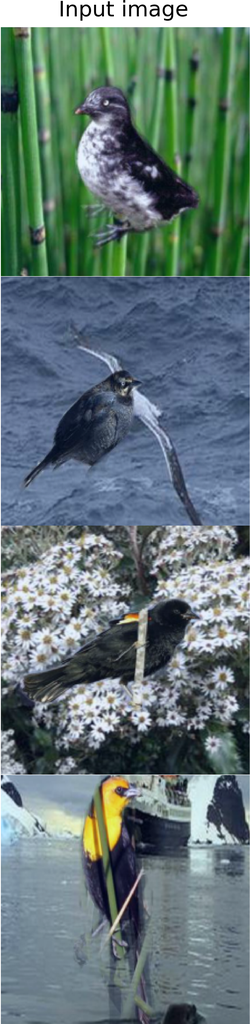

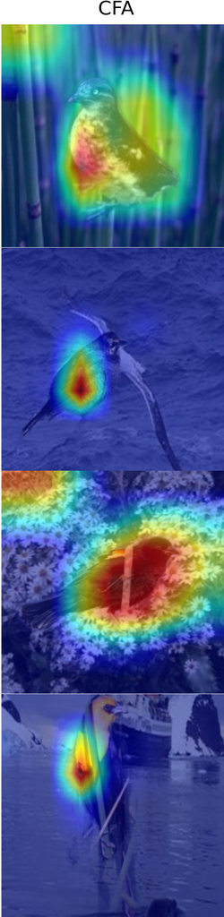

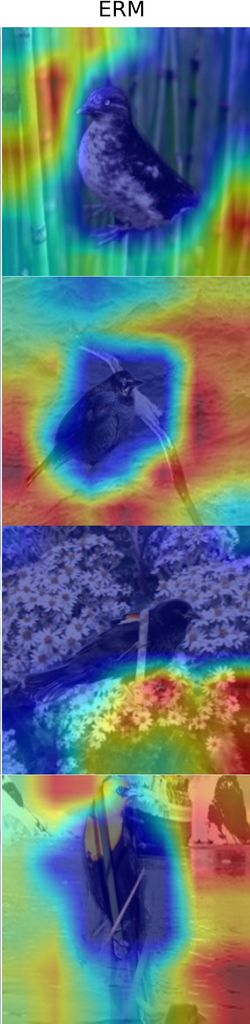

Vermelho = regiões usadas na decisão. **ERM** (treinamento convencional) frequentemente privilegia o fundo; **CFA** (modelo corrigido) concentra-se nas aves.

Fonte: [Venkataramani et al. (2024), *Causal Feature Alignment: Learning to Ignore Spurious Background Features*, Figura 8](https://openaccess.thecvf.com/content/WACV2024/papers/Venkataramani_Causal_Feature_Alignment_Learning_To_Ignore_Spurious_Background_Features_WACV_2024_paper.pdf).

## E se?

**E se um modelo que funciona bem sofrer uma falha catastrófica após uma mudança minúscula na entrada?**

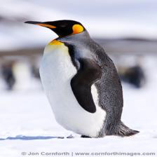

**Original:** *king penguin*

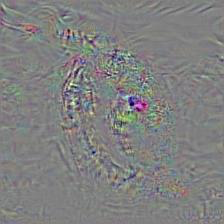

**Perturbação adversarial** ×10

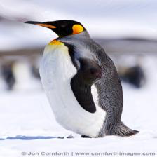

**Resultado:** *chihuahua*

Exemplo com a arquitetura VGG. Fonte: [Xie et al. (2018), *Mitigating Adversarial Effects Through Randomization*, Figura 1](https://openreview.net/forum?id=Sk9yuql0Z).

## E se?

**E se eu perguntar algo a uma LLM e ela explicar a própria resposta, como saberei se a explicação é confiável?**

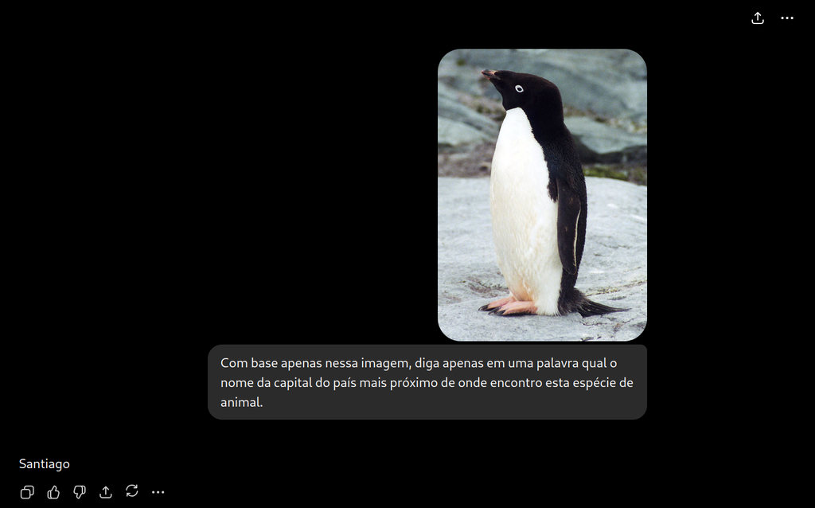

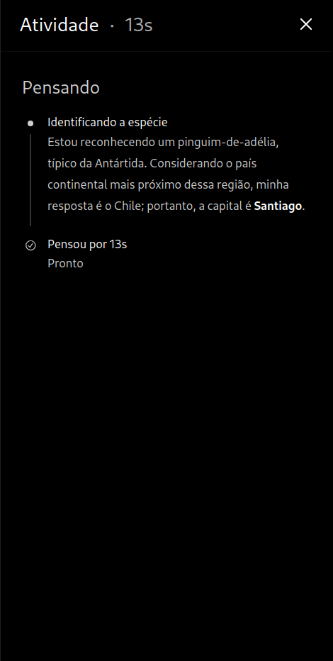

**Modelo exibido:** GPT-5.6 Sol

## E se?

**E se eu quiser saber como investigar todas essas perguntas?**

**Então venha às próximas aulas.**

[figure not shown]

Fonte: [*Pingu Has a Day Off* — Gallery](https://pingu.fandom.com/wiki/Pingu_Has_a_Day_Off/Gallery).

## Referências

- Mitchell, T. M. (1997). *Machine Learning*. McGraw-Hill.
- Géron, A. (2019). *Hands-On Machine Learning with Scikit-Learn, Keras, and TensorFlow*.
- Domingos, P. (2012). [A Few Useful Things to Know about Machine Learning](https://homes.cs.washington.edu/~pedrod/papers/cacm12.pdf).
- Molnar, C. (2025). [*Points, Rules, Weights, Distributions*](https://mindfulmodeler.substack.com/p/points-rules-weights-distributions)
- Tharwat A. (2020). Classification assessment methods. Applied Computing and Informatics 17(1):168–192 DOI 10.1016/j.aci.2018.08.003.
- Horst, A. M., Hill, A. P., & Gorman, K. B. (2020). [*palmerpenguins: Palmer Archipelago (Antarctica) penguin data*](https://allisonhorst.github.io/palmerpenguins/).
- Material da disciplina INF01017: *Introdução ao Aprendizado de Máquina* e *Introdução ao Aprendizado Supervisionado*, Mariana Recamonde-Mendoza.
- [Fundamentos de Inteligência Artificial | Inteligência Artificial na Educação](https://youtu.be/R1pJvfWNFzg?si=bR_ZLaeFCfVX4c8a), Bruno Iochins Grisci.

## Próxima aula

**[Aula 02: Dados e Atributos](https://brunogrisci.github.io/aulas-interpretabilidade/aula02.html)**

## Sobre os slides

Slides por [Bruno Iochins Grisci](https://brunogrisci.github.io/) com base nas referências da disciplina, em especial o livro [*Interpretable Machine Learning: A Guide for Making Black Box Models Explainable*](https://christophm.github.io/interpretable-ml-book/). 3. ed. (2025) por [Christoph Molnar](https://christophmolnar.com/).

Slides desenvolvidos usando [Quarto](https://quarto.org/) e [reveal.js](https://revealjs.com/) com auxílio de Codex e GPT-5.6 Sol.

## Licença e direitos autorais

© 2026 [Bruno Iochins Grisci](https://brunogrisci.github.io/). Alguns direitos reservados.

Exceto quando indicado em contrário, os textos, diagramas e demais elementos autorais próprios desta apresentação estão licenciados sob a Licença Creative Commons Atribuição–NãoComercial 4.0 Internacional (CC BY-NC 4.0):

https://creativecommons.org/licenses/by-nc/4.0/deed.pt-br

É permitida a cópia e o compartilhamento do material, para fins não comerciais, mediante atribuição adequada da autoria.

Imagens, citações, marcas, logotipos e demais materiais de terceiros não estão abrangidos por esta licença e permanecem sujeitos às respectivas licenças e direitos autorais indicados junto a cada item.

Para uso comercial, adaptações ou outras permissões, entre em contato com o [autor](https://brunogrisci.github.io/).